# [EDA]

Vinay S

27 September 2017

### =========================================================================

## Q No 1

#### *Data Mart*

- A database, or collection of databases, designed to help managers make strategic decisions about their business. Whereas a data warehouse combines databases across an entire enterprise, data marts are usually smaller and focus on a particular subject or department. Some data marts, called dependent data marts,are subsets of larger data warehouses.
- Listed below are the reasons to create a data mart:
  - To partition data in order to impose access control strategies.
  - To speed up the queries by reducing the volume of data to be scanned.
  - To segment data into different hardware platforms.
  - To structure data in a form suitable for a user access tool.

### ——————————–

#### *Data Lake*

- A data lake is a storage repository that holds an enormous amount of raw or refined data in native format until it is accessed.
- The term data lake is usually associated with Hadoop-oriented object storage in which an organization’s data is loaded into the Hadoop platform and then business analytics and data-mining tools are applied to the data where it resides on the Hadoop cluster.
- Data lakes can also be used effectively without incorporating Hadoop depending on the needs and goals of the organization.
- Its also called **large data pool**
- eg
  - 1. Microsoft Azure Data lake
  - 2. IBM Data lake

### ——————————–

#### *Data warehouse*

- A data warehouse is constructed by integrating data from multiple heterogeneous sources. It supports analytical reporting, structured and/or ad hoc queries and decision making.
- The term “Data Warehouse” was first coined by Bill Inmon in 1990. According to Inmon, a data warehouse is a subject oriented, integrated, time-variant, and non-volatile collection of data. This data helps analysts to take informed decisions in an organization.
- A data warehouse is a database, which is kept separate from the organization’s operational database.
- There is no frequent updating done in a data warehouse.
- A data warehouse helps executives to organize, understand, and use their data to take strategic decisions.

### ——————————–

#### *DB2*

- DB2 is a family of relational database management system (RDBMS) products from IBM that serve a number of different operating system platforms.
- According to IBM, DB2 leads in terms of database market share and performance.
- Although DB2 products are offered for UNIX-based systems and personal computer operating systems, DB2 trails Oracle’s database products in UNIX-based systems and Microsoft’s Access in Windows systems

### —————————————————————————————————————–

## Q No 2

### Supervised and Unsupervised Learning

| Supervised | Unsupervised |
| --- | --- |
| In Supervised learning we find the function f which can be used to assign a class or value to unseen observations | Unsupervised learning is a technique which deals without the labelling of observations |
| Classification and regression are main two aspects come under superviswd learning | Clustering is the type of unsupervised learning |
| In supervised learning model performance can be checked by comparing actual labels with predicted labels | Model performance measure is quite difficult in unsupervised learning |
| There is trining and testing data in supervised learning | There is no training and test data in unsupervised learning |

### —————————————————————————————————————–

## Q No 3

### a) Model

```r
data<-read.csv("data_pca.csv",header = TRUE)
pca<-prcomp(data,scale. = TRUE)
```

#### ————————————-

### b) Screeplot

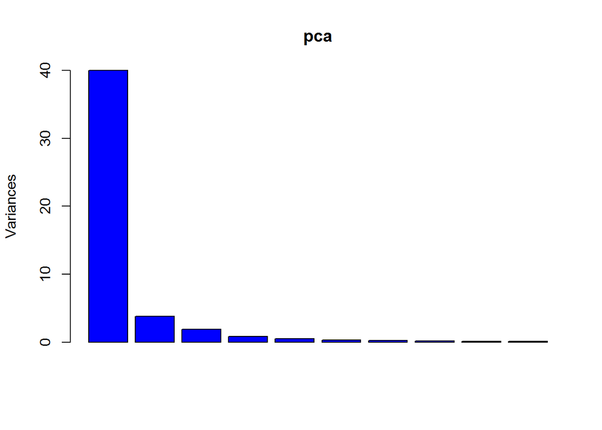

```r
screeplot(pca,ylim=c(0,40),col="blue")
```

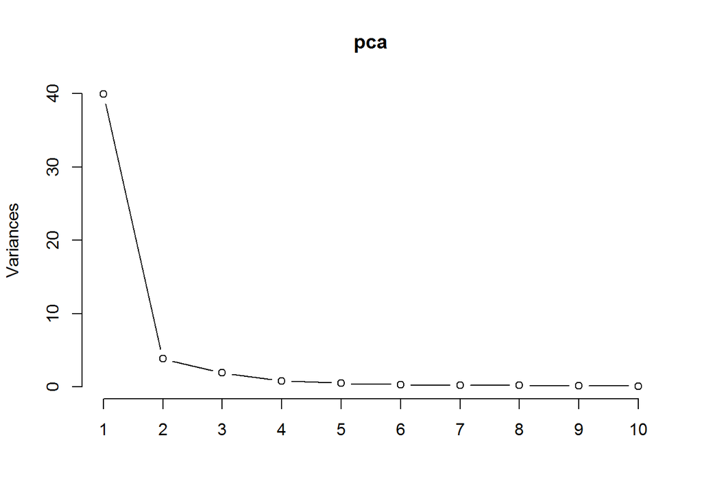

```r
screeplot(pca,ylim=c(0,40),type="l")
```

#### ————————————-

### c) Model components

#### `sdev`

```r
sdev <- pca$sdev
```

- `sdev` is a vector of standard deviation of all principle components in the model.
- It is always in decreasing order, the component having more variation occurs first.
- By squaring `sdev` we get the variances of corresponding principle components, which are nothing but the Eigen values of the correlation matrix of given data.
- One can decide how many principle components should be retained for fixed level of confidence.

#### ————————————-

#### `rotation`

```r
rotation <- pca$rotation
```

- `rotation` is a square matrix, which is nothing but the eigen vector of correlation/covariance matrix of data
- `rotation` in `prcomp` is equivalent to `loadings` in `princomp`.
- This is used as weight matrix(non significant columns set to be zero) for reconstructing the original data values.
- The transpose of the same is multiplied to the principle components to reconstruct the data.

#### ————————————-

#### `center` and `scale`

```r
center <- pca$center
scale <- pca$scale
```

- `center` is a vector of all variable means.
- `scale` is a vector of all variable standard deviations.
- both are necessary for standardising the data.

#### ————————————-

#### `x`

```r
x <- pca$x
  #scale(data)%*%eigen(cor(data))$vector
  #scale(data)%*%pca$rotation
```

- `x` is equivalent to `scores` in `princomp`
- x is nothing but tne principle component matrix
- It is matrix multiplication of scaled data and the eigen vectors matrix.

#### ————————————-

#### Eigen values by using `sdev`

```r
eigen.value <- (pca$sdev)^2
eigen.value1<-eigen(cor(data))$values

cor(eigen.value,eigen.value1)
```

```
## [1] 1
```

#### ————————————-

### d) cumulative variance explained

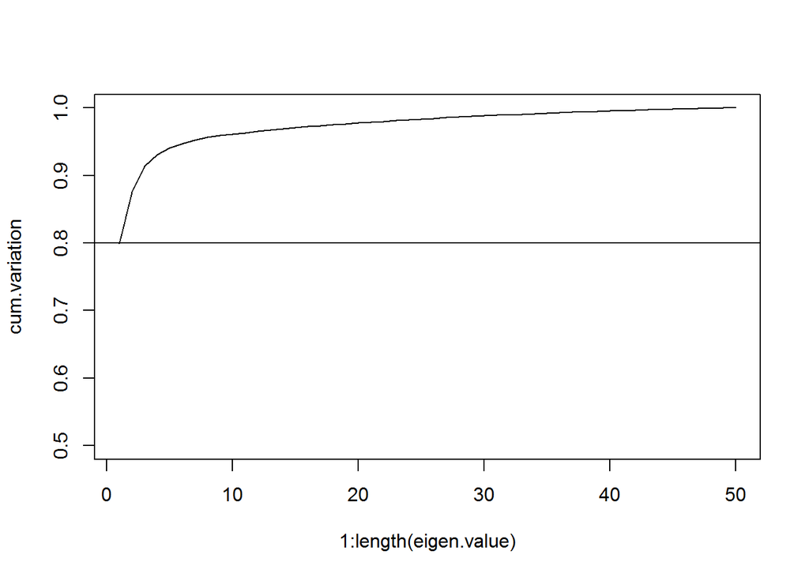

```r
cum.variation <- cumsum(eigen.value)/sum(eigen.value)
plot(x=1:length(eigen.value),y=cum.variation,type = "l",ylim=c(0.5,1))
abline(h=0.8)
```

#### ————————————-

### e) Number of PC’s for retaining 80% of variation

```r
sum(cum.variation <= 0.80)
```

```
## [1] 1
```

- Only first principle component is enough for explaining 80% of variation in the data.

#### ————————————-

### f) `biplot`

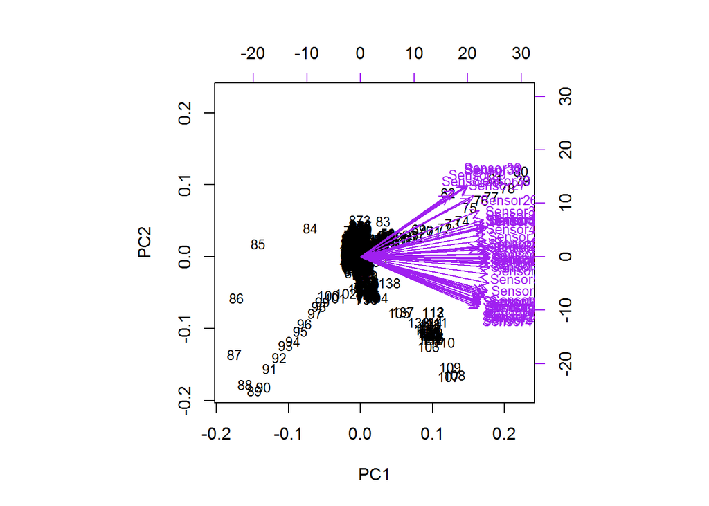

```r
par(pty="m")
biplot(pca,choices = c(1,2),col=c("black","purple"),cex=.8)
```

- There are two things to consider in biplot output
  - The direction of arrow
  - The magnitude (length) of arrow
- As all the arrows are projected almost in same direction, we conclude that they vary in same direction.
- Most of the arrows are alongside of PC1 axis, means as PC1 increases there is increase in these variables and vice versa.
- The length of arrow gives the amount of variation in corresponding variable as compared to other variables.
- PC2 is not that much matter to any of the variables because most of them are perpendicular to PC2,except the terminal ones.

### ————————————————————————————————————————-

## Q No 4

### Loading the airquality dataset

```r
air<-airquality
```

### a. Percentage of nulls in each column

```r
percent.Null<-apply(air,2,function(x) sum(is.na(x))/length(x)*100)
percent.Null1<-air%>%summarise_all(funs(100*mean(is.na(.))))

percent.Null
```

```
##     Ozone   Solar.R      Wind      Temp     Month       Day
## 24.183007  4.575163  0.000000  0.000000  0.000000  0.000000
```

#### ——————————————–

### b.“aggr” plot for vizualising % of missing values

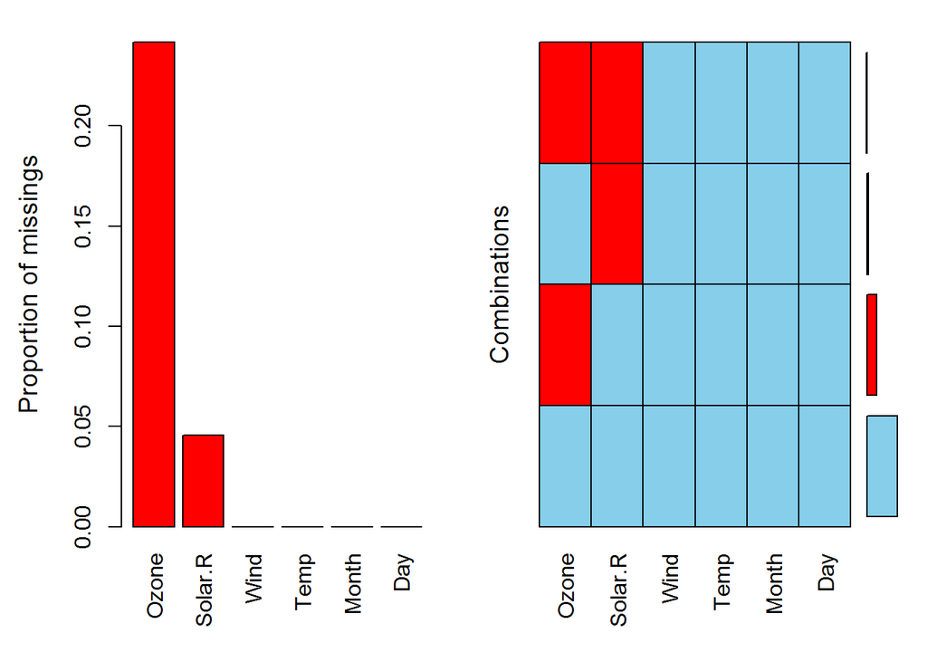

#### ——————————————–

### c. Impute missing values in the ozone column using package `mice`

#### Getting pattern of missing values

```r
library(mice)
md.pattern(air)
```

```
##     Wind Temp Month Day Solar.R Ozone
## 111    1    1     1   1       1     1  0
##  35    1    1     1   1       1     0  1
##   5    1    1     1   1       0     1  1
##   2    1    1     1   1       0     0  2
##        0    0     0   0       7    37 44
```

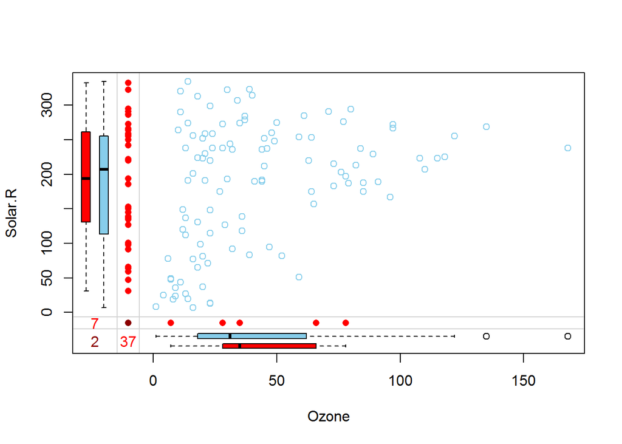

```r
marginplot(air[c(1,2)])
```

The pattern tells us whether the missing values are random or if there is any pattern in there distribution.

- 111 samples have no missing values
- 35 samples have missing values in Ozone
- 5 samples have missing values in Solar.R
- 2 samples have missing values in both Solar.R and Ozone
- Total missing values in airquality are 44, out of which 37 in Ozone and 7 in Solar.R
- Marginplot is vizualisation of distribution of Ozone for missing and available values of Solar.R and vice-versa.

#### ————————————-

#### Imputing the missing data

```r
imp.air <- mice(air,m=5,maxit=50,meth='pmm',seed=500)  # One can use different methods instead `pmm`
summary(imp.air)
```

```
## Multiply imputed data set
## Call:
## mice(data = air, m = 5, method = "pmm", maxit = 50, seed = 500)
## Number of multiple imputations:  5
## Missing cells per column:
##   Ozone Solar.R    Wind    Temp   Month     Day
##      37       7       0       0       0       0
## Imputation methods:
##   Ozone Solar.R    Wind    Temp   Month     Day
##   "pmm"   "pmm"   "pmm"   "pmm"   "pmm"   "pmm"
## VisitSequence:
##   Ozone Solar.R
##       1       2
## PredictorMatrix:
##         Ozone Solar.R Wind Temp Month Day
## Ozone       0       1    1    1     1   1
## Solar.R     1       0    1    1     1   1
## Wind        0       0    0    0     0   0
## Temp        0       0    0    0     0   0
## Month       0       0    0    0     0   0
## Day         0       0    0    0     0   0
## Random generator seed value:  500
```

- It gives 5 imputed data sets for each missing observations of each column.

#### Checking for some columns

```r
imp.air$imp$Ozone
```

```
##       1   2   3   4   5
## 5     6   1  14  18   6
## 10   12  23  30  21  23
## 25    8  19   6  14  19
## 26   32  32  28  19  19
## 27   13  12  37  18   7
## 32   59  20  59  36  78
## 33   16  31  23  11  18
## 34    1  13  13  37  13
## 35   44  37   7  35  71
## 36   35 108  59  35  39
## 37   14  16  30  30  20
## 39  115  91 115 168  82
## 42   64  77 168  66  78
## 43   61  91  79  82  91
```

[output cut: 23 more lines]

```r
imp.air$imp$Solar.R
```

```
##      1   2   3   4   5
## 5  135 259 201 238  47
## 6  285 225 120 322 307
## 11 275 255 255 138  66
## 27 238  20 230 238 223
## 96 225 267 175 187 272
## 97  83 236 254 258 139
## 98 314 203 225  92 167
```

#### Replacing missing values with imputed values

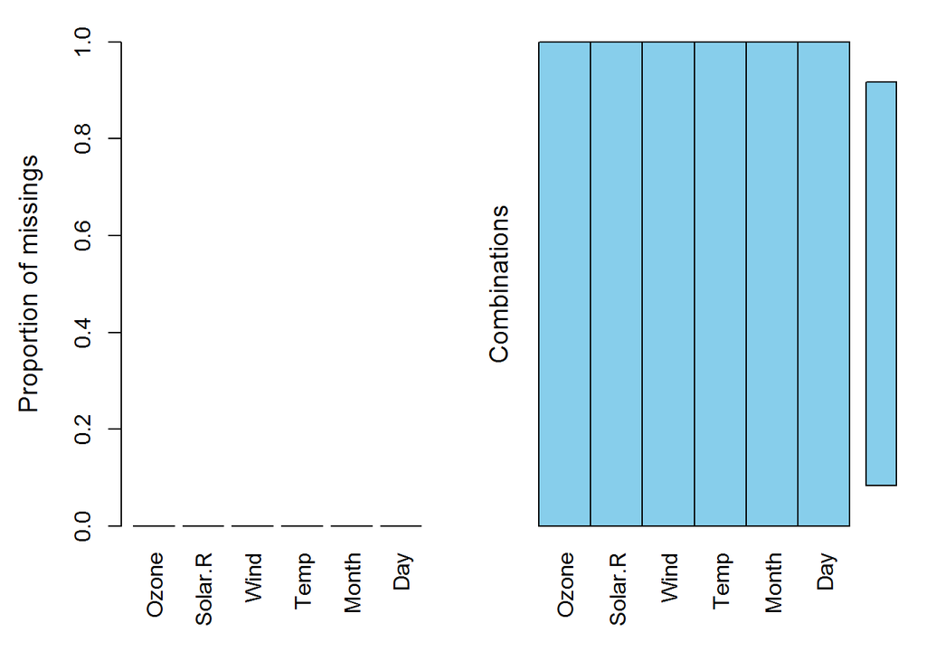

```r
# I Prefered the second data set of imputed
complete.air<-complete(imp.air,2)

aggr(complete.air)
```

#### distribution of original and imputed data

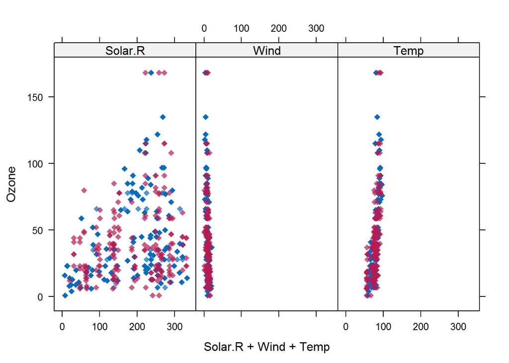

```r
library(lattice)
xyplot(imp.air,Ozone ~Solar.R+Wind+Temp,pch=18,cex=1)  # Scatterplot
```

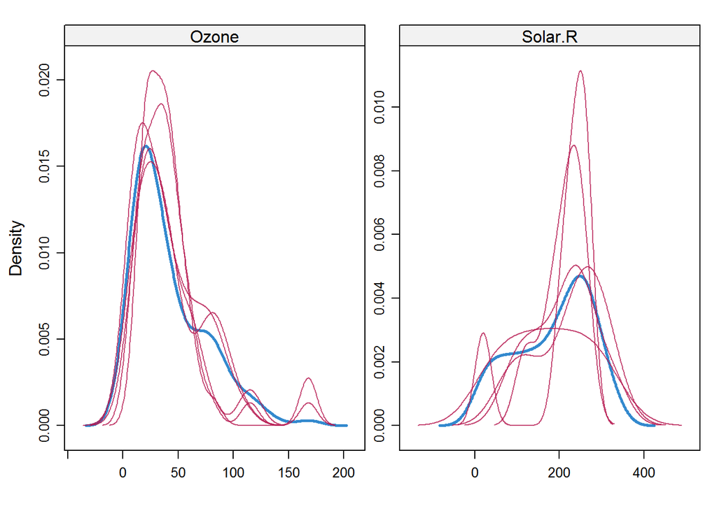

```r
densityplot(imp.air)    # Density plot
```

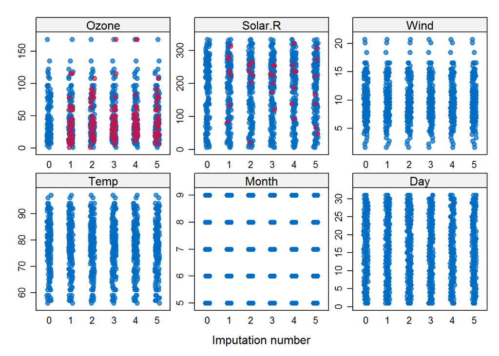

```r
stripplot(imp.air, pch = 20, cex = 1.2)   # strip plot
```

- The observed values are in bluecolor while imputed data is in magenta colour. The pattern says that the imputed values are plausible.

### ————————————————————————————————————————-